# Simulating CO T->P leakage from bandpass mismatch

We injected bandpass mismatches by simulating 1 yr of LB signal -only observations performed by 2 detector pair. We model the observed TOD signal as of the two detectors A, B as :

$$ d^A_t = f s_{CO} $$ $$ d^B_t = \epsilon f s_{CO} $$

where $f$ and $\epsilon $ parametrize the bandpass mismatch of the detector pair and $s_{CO} $ is the scanned CO intensity only map, $m_{CO}$ ( no polarization, $Q=U=0$) with a pointing matrix $A$ encoding the LB scanning strategy, i.e. : $$ s_{CO} = A m_{CO} $$

If we consider pair sum and pair differences : $$ d^+ = \frac{d^A +d^B}{2} = \frac{f(1+\epsilon)} {2} s_{CO} $$

$$ d^- = \frac{d^A -d^B}{2} = \frac{f(1-\epsilon)} {2} s_{CO} $$

We can estimate $m_{leak} = (Q, U)_{leak}$ maps from $d^-$ timestream as : $$ m_{leak} = (A^t A)^{-1} A^t d^-= (A^t A)^{-1} A^t \frac{f(1-\epsilon)} {2} s_{CO} $$ for an optimized scanning strategy we can approximate : $$ (A^t A)^{-1} \approx \begin{bmatrix} 1 & 0 & 0 \\ 0& 2 & 0 \\ 0 & 0 & 2 \end{bmatrix} $$ so that: $$ m_{leak} = f(1-\epsilon ) A^t s_{CO}=f(1-\epsilon ) A^t A\, m_{CO} $$

### Getting a consistent notation with Tommaso

In these [slides](https://wiki.kek.jp/display/cmb/Systematics+JSG+meeting+page?preview=/75006618/98272282/CO.pdf) presented by Tommaso, he uses a slightly different notation as compared to the one above. Notice that we get the same result if :

$$\Delta_{Tom} \equiv f (1- \epsilon)$$

In the following simulations I've run TOAST on a configuration similar to the Tommaso's one:

- `nside=64`, $Ndet=114$, $\Delta=7.5$ %
- one on hand we want to check whether the cross-link approximation (rescaling with $\sqrt{N_{det}$) is correct
- on the other hand, this will provide consistency checks between the two approaches

I can run bandpass mismatch sims with two different option:

1. same for all detector pairs,i.e. $f= 0.5$ and $\epsilon=0.85 $, so that $\Delta=7.5 \% $
2. random mismatch per detector pair, i.e. $f$ uniform between 0 and 1, $\epsilon $ s.t. $f (1- \epsilon)=7.5 \% $

## Constant mismatches

```python
import pylab as pl
from  numpy.random import normal
import numpy as np
import healpy as hp
from scipy.signal import periodogram
from pylab import cm
cmap = cm.get_cmap('RdYlBu')
cmap.set_under('w')

dirmaps='/Users/peppe/work/satellite_sims/CO_bandpass/'
```

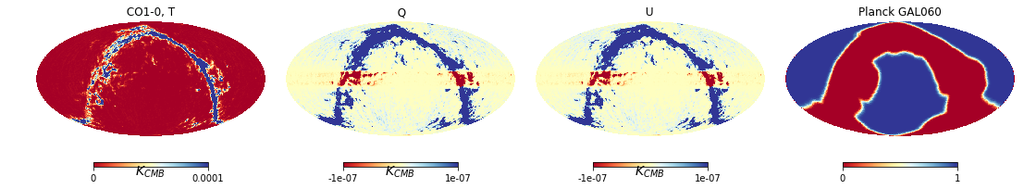

```python
mco10b=hp.read_map(dirmaps+'madam_bmap_012.fits',field=range(3), verbose=False  )
mask =hp.read_map(dirmaps+'HFI_Mask_Gal060-apo2_256_R2.00_Ecl.fits', verbose=False)
fig=pl.figure(figsize=(15,8))
mco10b[0]/=0.5
hp.mollview(mco10b[0] , cmap=cmap , sub=141, fig=fig,max=.0001,min=0., title= ' CO1-0, T '  , unit= r'$K_{CMB}$ ')
hp.mollview(mco10b[1] , cmap=cmap , sub=142, fig=fig , title= '  Q ' , unit=  r'$K_{CMB}$ ', min=-1e-7, max=1e-7)
hp.mollview(mco10b[2], cmap=cmap , sub=143, fig=fig ,  title= ' U ' , unit=  r'$K_{CMB}$ ', min=-1e-7, max=1e-7)

hp.mollview(mask,title='Planck GAL060' ,  cmap=cmap,sub=144,fig=fig)
```

## Random Mismatches

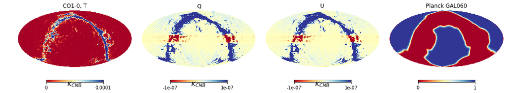

```python
mco10a=hp.read_map(dirmaps+'madam_bmap_013.fits',field=range(3), verbose=False  )
mask =hp.read_map(dirmaps+'HFI_Mask_Gal060-apo2_256_R2.00_Ecl.fits', verbose=False)
fig=pl.figure(figsize=(15,8))
mco10a[0]/=0.5
hp.mollview(mco10a[0] , cmap=cmap , sub=141, fig=fig, max=.0001,min=0., title= ' CO1-0, T '  , unit= r'$K_{CMB}$ ')
hp.mollview(mco10a[1] , cmap=cmap , sub=142, fig=fig , title= '  Q ' , unit=  r'$K_{CMB}$ ', min=-1e-7, max=1e-7)
hp.mollview(mco10a[2], cmap=cmap , sub=143, fig=fig ,  title= ' U ' , unit=  r'$K_{CMB}$ ', min=-1e-7, max=1e-7)

hp.mollview(mask,title='Planck GAL060' ,  cmap=cmap,sub=144,fig=fig)
```

```python
from IPython.display import HTML

HTML('''<script>
code_show=true;
function code_toggle() {
 if (code_show){
 $('div.input').hide();
 } else {
 $('div.input').show();
 }
 code_show = !code_show
}
$( document ).ready(code_toggle);
</script>
<form action="javascript:code_toggle()"><input type="submit" value="Click here to toggle on/off the raw code."></form>''')
```

As one can notice, the T-P leakage due to bandpass mismatches is essentially equivalent in both cases, in fact the B power spectra show a similar amplitude both for random and constant mismatches. The reason is mostly due to the fact that the polarization maps are proportional to $\Delta$ being the same (7.5%) for both cases.

```python
lmax=3*hp.get_nside(mco10b)
clmasked =hp.anafast([m*mask for m in mco10b] , lmax=lmax )
clmaskeda =hp.anafast([m*mask for m in mco10a] , lmax=lmax )
```

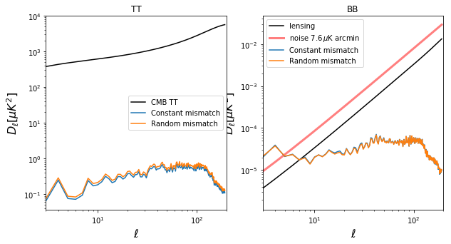

```python
cl = pl.loadtxt('../Class_planck2015_r0_cl_lensed.dat')
l=pl.arange(2, lmax+1)
Nl =lambda w: (pl.pi /180. /60. * w)**2
wp=7.6 # uK arcmin
Nl0= Nl(wp)
f=0.5
eps=0.3
ll = l*(l+1)/2./pl.pi
pl.figure(figsize=(10,5))
pl.subplot(122)
pl.title('BB')
pl.loglog(l, cl[ 2:lmax+1,3] *ll   ,'k', label='lensing')
pl.xlabel(r'$\ell$', fontsize=16)
pl.ylabel(r'$D_{\ell}    [ \mu K^2 ]$', fontsize=16)
pl.loglog(l, ll *Nl0,'r', alpha=.5, linewidth=3, label='noise '+r'$7.6 \,\mu $K arcmin ')
pl.loglog(l, ll*clmasked[2,2:lmax+1]*1e12,label='Constant mismatch' )
pl.loglog(l, ll*clmaskeda[2,2:lmax+1]*1e12,label='Random mismatch' )

#pl.loglog(cb[0], cb[3]*1e12*f**2*(1-eps)**2,':', lw=5, label='CO 1-0  leakage' )
pl.legend()
#pl.ylim([1e-4,1e-1])
foo=pl.xlim([3 ,200])

pl.subplot(121)
pl.title('TT')
pl.loglog(l, cl[ 2:lmax+1,1] *ll   ,'k', label='CMB TT')
pl.xlabel(r'$\ell$', fontsize=16)
pl.ylabel(r'$D_{\ell}    [ \mu K^2 ]$', fontsize=16)
pl.loglog(l, ll*clmasked[0,2:lmax+1]*1e12, label='Constant mismatch' )
pl.loglog(l, ll*clmaskeda[0,2:lmax+1]*1e12,label='Random mismatch' )

#pl.loglog(cb[0], cb[3]*1e12*f**2*(1-eps)**2,':', lw=5, label='CO 1-0  leakage' )
pl.legend()
#pl.ylim([1e-4,1e-1])
foo=pl.xlim([3 ,200])
```